# Exercise 3 - Logistic regression

### Age

Another variable we looked at was age. We look at the variables in the same way as before

```r
alc %>% group_by(age,high_use) %>% summarise(count = n())
```

```
## # A tibble: 12 x 3
## # Groups:   age [7]
##      age high_use count
##    <int> <lgl>    <int>
##  1    15 FALSE       63
##  2    15 TRUE        18
##  3    16 FALSE       79
##  4    16 TRUE        28
##  5    17 FALSE       64
##  6    17 TRUE        36
##  7    18 FALSE       54
##  8    18 TRUE        27
##  9    19 FALSE        7
## 10    19 TRUE         4
## 11    20 FALSE        1
## 12    22 TRUE         1
```

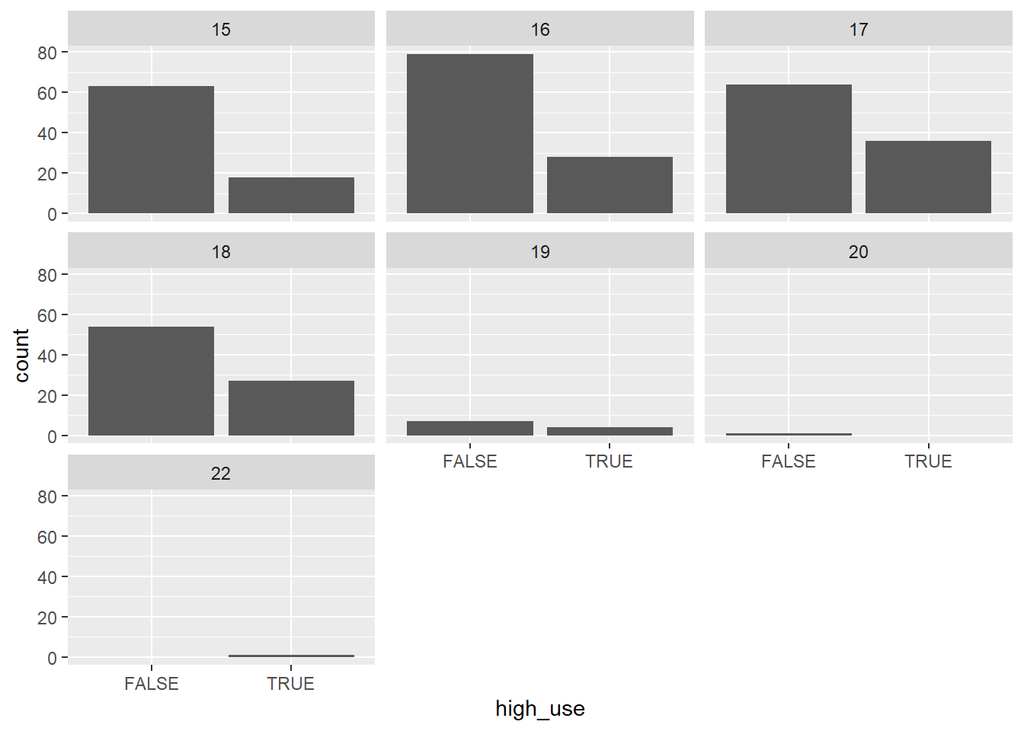

```r
g <- ggplot(data = alc, aes(x=high_use))
g+facet_wrap("age")+geom_bar()
```

Once again, the hypothesis appeared to be true, drinking does increase with age.

### Study hours

The amount of hours spent on studying seems also correlate with drinking.

```r
alc %>% group_by(studytime,high_use) %>% summarise(count = n())
```

```
## # A tibble: 8 x 3
## # Groups:   studytime [4]
##   studytime high_use count
##       <int> <lgl>    <int>
## 1         1 FALSE       58
## 2         1 TRUE        42
## 3         2 FALSE      135
## 4         2 TRUE        60
## 5         3 FALSE       52
## 6         3 TRUE         8
## 7         4 FALSE       23
## 8         4 TRUE         4
```

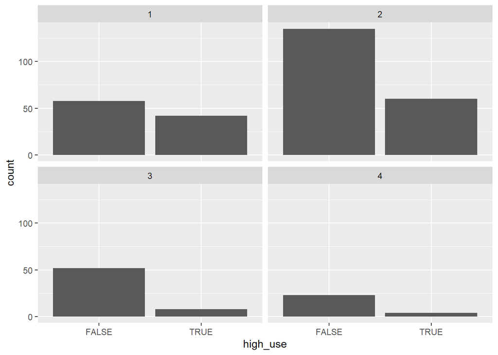

```r
g <- ggplot(data = alc, aes(x=high_use))
g+facet_wrap("studytime")+geom_bar()
```

The percentage of heavy drinkers seems clearly decrease with the amount of hours spent on studying. As study time most likely correlates with academic performance in general, we most likely could have chosen course grades (G1,G2,G3) to get a similar result.

### Parent’s cohabitation status

Last we explored the possibility that whether or not the parent cohabit could have an effect on drinking habits.

```r
alc %>% group_by(Pstatus,high_use) %>% summarise(count = n())
```

```
## # A tibble: 4 x 3
## # Groups:   Pstatus [2]
##   Pstatus high_use count
##   <chr>   <lgl>    <int>
## 1 A       FALSE       26
## 2 A       TRUE        12
## 3 T       FALSE      242
## 4 T       TRUE       102
```

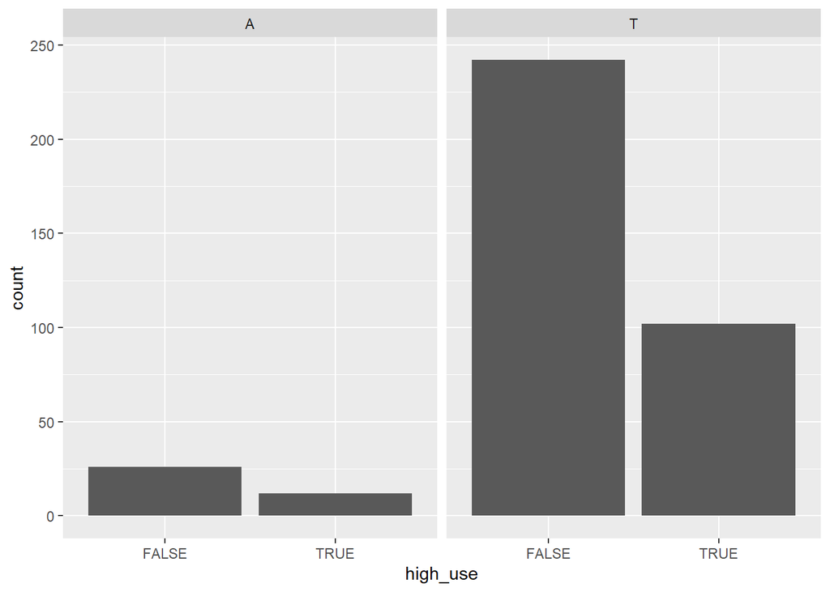

```r
g <- ggplot(data = alc, aes(x=high_use))
g+facet_wrap("Pstatus")+geom_bar()
```

In this case, there seems to be no clear relation between the variables.

## Logistic regression modeling

I included all the considered variables except the parent cohabitation status in the logistic regression model, since it did not seem to affect the amount the students drank.

```r
mdl <- glm(high_use ~ sex + studytime + age, data = alc, family = "binomial")
summary(mdl)
```

```
##
## Call:
## glm(formula = high_use ~ sex + studytime + age, family = "binomial",
##     data = alc)
##
## Deviance Residuals:
##     Min       1Q   Median       3Q      Max
## -1.4737  -0.8178  -0.6672   1.1747   2.2964
##
## Coefficients:
##             Estimate Std. Error z value Pr(>|z|)
## (Intercept)  -3.9603     1.7043  -2.324  0.02014 *
## sexM          0.6687     0.2440   2.741  0.00612 **
## studytime    -0.4851     0.1594  -3.042  0.00235 **
## age           0.2225     0.1001   2.224  0.02615 *
## ---
## Signif. codes:  0 '***' 0.001 '**' 0.01 '*' 0.05 '.' 0.1 ' ' 1
##
## (Dispersion parameter for binomial family taken to be 1)
##
##     Null deviance: 465.68  on 381  degrees of freedom
## Residual deviance: 435.64  on 378  degrees of freedom
## AIC: 443.64
##
## Number of Fisher Scoring iterations: 4
```

The model shows that each of the selected variables have predictive power, as the statistical significance of each model parameter is at least < 0.05. The intercept is quite low, which is follows from the fact that we included age in the regression; since the students are at least 15-16 year old, the positive contribution from age needs to be balanced by a negative intercept. The negative coefficient for study time shows that the amount of studying correlates negatively with the alcohol consumption, whereas being male has an positive effect on the likelihood of excessive drinking (it seems that R has automatically assigned a numerical value 0.0 to females and 1.0 to males in order to perform the regression).

```r
library(DescTools)
OR <- coef(mdl) %>% exp
CI <- MeanCI(OR)
cbind(OR, CI)
```

```
##                     OR         CI
## (Intercept) 0.01905673  0.9589365
## sexM        1.95179032 -0.3632318
## studytime   0.61565757  2.2811048
## age         1.24924140  0.9589365
```

The same interpretation can be made from the odds ratios. Since odds > 1 are positively associated with success, both male sex and age increase the probability of a student drinking much, the opposite is true for studying much OR = 0.62 (< 1.0).

## Testing the predictive power of the model

Last, I tested the models predictive power by calculating the probability of high alcohol use using the original data set, and then comparing the result to the actual value. The results can be summarized in a so-called confusion matrix, which tabulates the predictions versus the ground truth.

```r
probabilities <- predict(mdl, type = "response")
alc <- mutate(alc, probability = probabilities)
alc <- mutate(alc, prediction = probability>0.5)
alc %>% group_by(high_use,prediction) %>% summarise(ratio = n())
```

```
## # A tibble: 4 x 3
## # Groups:   high_use [2]
##   high_use prediction ratio
##   <lgl>    <lgl>      <int>
## 1 FALSE    FALSE        251
## 2 FALSE    TRUE          17
## 3 TRUE     FALSE         95
## 4 TRUE     TRUE          19
```

The values in the summary are the amounts of true and false positives, and true and false negatives. The 0.71 accuracy (accuracy = (TP+TN)/Ntot)) of this model seems to me surprisingly good (considering my low expectations). For a coin toss, the value would be 0.5. On the other hand, the relatively good accuracy is explained by the low number of false positives. The number of false negatives is quite high, so overall this model is not so good in finding out students with a risk of high alcohol consumption.